# O2G Supply-Demand MAP Fit Report

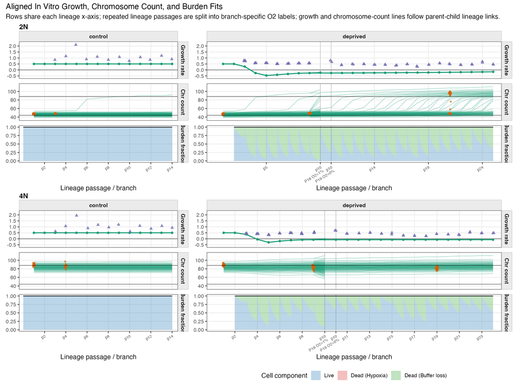

**Figure 3.2.2.3 Aligned Growth, Chromosome Count, and Burden Fit**

Composite in vitro fit view. The 2N and 4N cohort blocks are stacked vertically; each block contains growth rate, chromosome-count quantile, and burden-decomposition rows. Repeated lineage passages are split into branch-specific O2 x-axis labels rather than averaged together; growth-rate and chromosome-count lines follow parent-child lineage links, so parallel p10 branches both connect to their shared p9 parent. Observed growth-rate points are drawn at their own branch positions. In vitro burden components are live/dead fractions normalized by the displayed predicted cell components, so the burden row ranges from 0 to 1. Control and deprived panels use their own passage ranges, with rows aligned within each lineage panel.

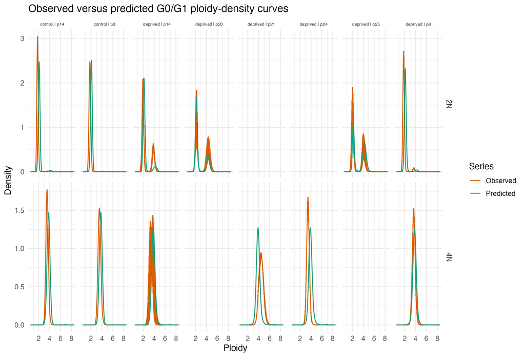

**Figure 3.2.2.4 Flow-Density Fit**

Observed G0/G1 ploidy-density curves are overlaid with the fitted flow-density prediction.

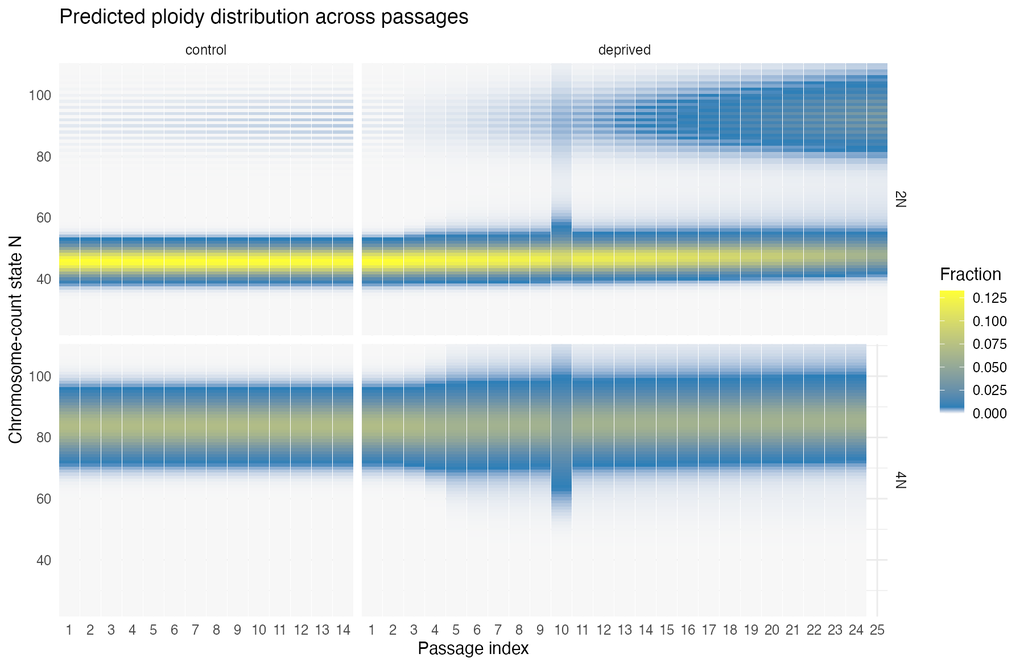

**Figure 3.2.2.5 Predicted Ploidy Distribution**

Full predicted chromosome-count distribution across in vitro passages.